# Prosper Loan Data Exploration

## Magalaweng Clive Mmakola

## Investigation Overview

### Univariate Exploration

- Most borrowers preffered the 36 months loan term and this might be because the borrower rate is more reasonable depending which type of borrower

### Multivariate-Exploration

- Whether a borrower is a homeowner or not alone does not seem to have more effect on the borrower is approved for the loan or not
- The loan amount one takes is hightly correlated to the amount they will have to pay monthly and this also applies to the rates and the term of the loan

## Dataset Overview

- This data set contains 113,937 loans with 81 variables on each loan, including loan amount, borrower rate (or interest rate), current loan status, borrower income, and many others.

## Key Insights for Presentation

- Whether a borrower is a homeowner or not alone does not seem to have more effect on the borrower is approved for the loan or not
- The loan amount one takes is hightly correlated to the amount they will have to pay monthly and this also applies to the rates and the term of the loan

## Count of Loans Per Term(IsBorrowerHomeowner)

- The loan 36 months loan term is mostly favoured by borrowers
- Borrowers who are not homeowners being the most with loans under the 36 month term and those who are homeowners being more in the 60 month loan term

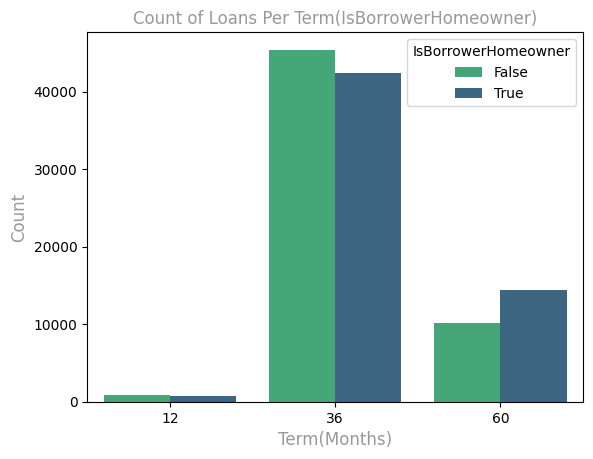

## Count of Loans Per Term (ProsperRating)

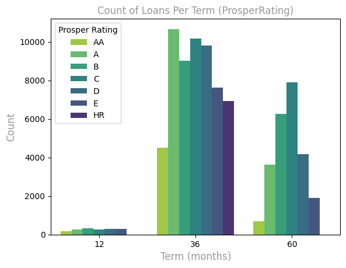

## Proportion of Loans for Each Income Range

- Borrowers with most loans listed fall in the `25_000 - 49_999` Dollars, followed by those in the `50_000 - 74_999` Dollars income range.
- Those in the high income range are less and this might be because they have no reasons to take loans or that they are a small portion of the data set.
- Those in the low income ranges also have the least loans listed and the reason for this might just be the same as the above mentioned reason of the high income range borrowers.

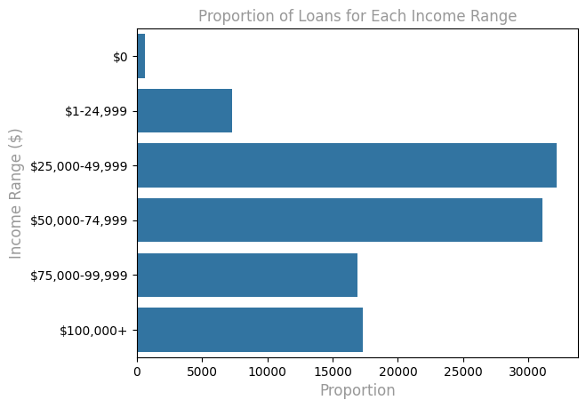

## Borrower APR vs Borrower Rate(IsBorrowerHomeowner)

- Being a homeowner does not really affect the rate as much.
- This might be because maybe some homeowners had a bad scores or ratings and so their rates increased

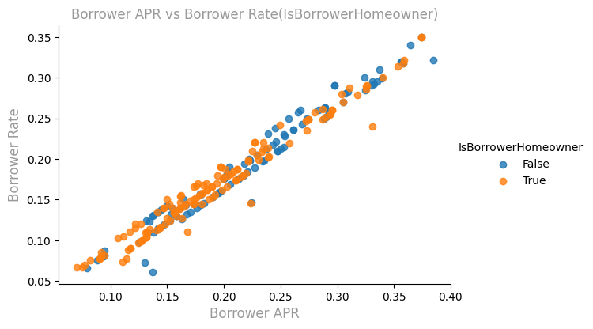

## Borrower APR vs Borrower Rate (Term)

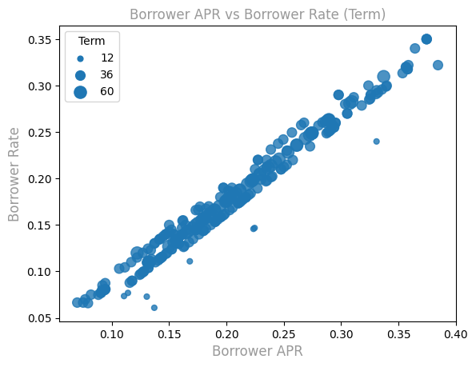